# Tuango - RFM Analysis for Mobile App Push Messaging

- Name:Qiuyi Lu
- GitLab id: rsm-q2lu

## Setup

Please complete this Rmarkdown document by answering questions 1-13 in `tuango.pdf` on Canvas (week4/). The code block below loads the data you need for this first Rmarkdown file. Create an HTML file with all your results and answers and push both the Rmarkdown and HTML file to GitLab when you are done. All results MUST be reproducible (i.e., the TA and I must be able to recreate the results without changes or errors)

Use “tuango_post.Rmd” to answer Question 14 in `tuango.pdf`

```r
## loading the data - this dataset must NOT be changed
tuango <- readr::read_rds("data/tuango.rds")
```

## Question answers

##### 1. What percentage of customers responded (i.e., bought anything) after the push message?

```r
ave_respon_rate=sum(tuango$buyer=='yes')/nrow(tuango)
ave_respon_rate
```

```
[1] 0.02980845
```

##### 2. What was the average amount spent on the Karaoke deal by customers that bought one (or more)? Use the ordersize variable for your calculation.

```r
one_more= tuango[tuango$ordersize>1,]
ave_amount=sum(one_more$ordersize)/nrow(one_more)
ave_amount
```

```
[1] 202.1288
```

##### 3. Create quintile variables for recency, frequency and monetary.

```r
recency=tuango$recency
frequency=tuango$frequency
monetary=tuango$monetary

rec_iq=xtile(recency,5)
fre_iq=xtile(frequency,5,rev = TRUE)
mon_iq=xtile(monetary,5,rev=TRUE)



tuango_new=tuango %>% mutate(rec_iq,fre_iq,mon_iq)
```

##### 4.Create bar charts showing the response rate (i.e., the proportion of customers who bought something) for this deal per recency, frequency, and monetary quintile (i.e., 3 plots).

```r
visualize(
  tuango_new,
  xvar = "rec_iq",
  yvar = "buyer",
  type = "bar",
  labs = list(
    y = "Proportion of buyers = 'yes'",
    x = "months since last purchase"
  ),
  custom = FALSE
)
```

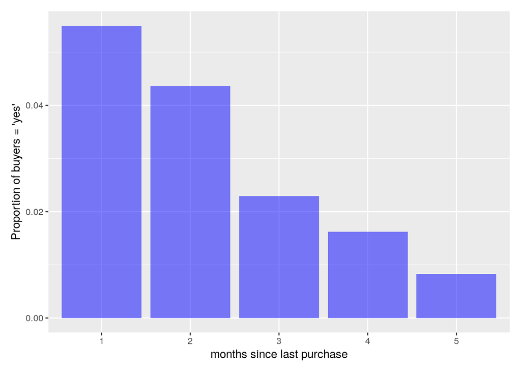

```r
visualize(
  tuango_new,
  xvar = "fre_iq",
  yvar = "buyer",
  type = "bar",
  labs = list(
    y = "Proportion of buyers = 'yes'",
    x = "Purchase frequency"
  ),
  custom = FALSE
)
```

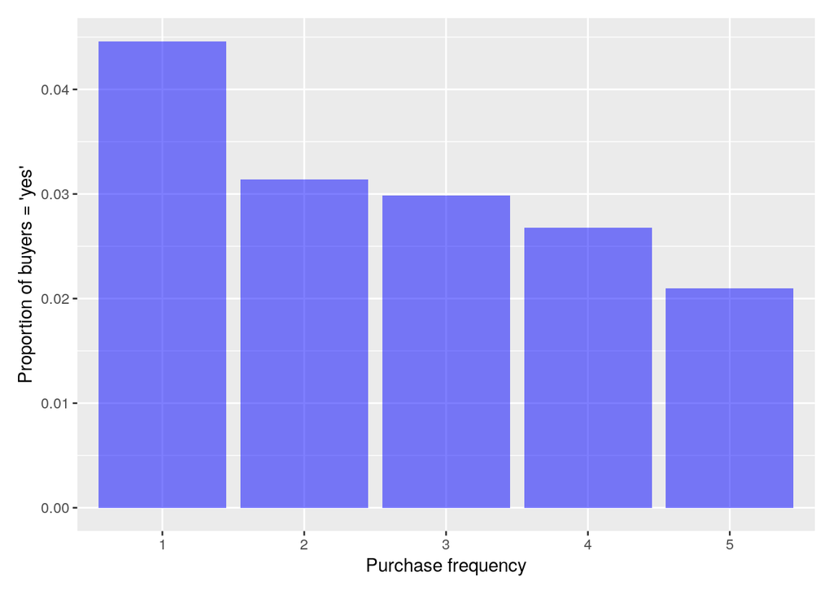

```r
visualize(
  tuango_new,
  xvar = "mon_iq",
  yvar = "buyer",
  type = "bar",
  labs = list(
    y = "Proportion of buyers = 'yes'",
    x = "Monetary value"
  ),
  custom = FALSE
)
```

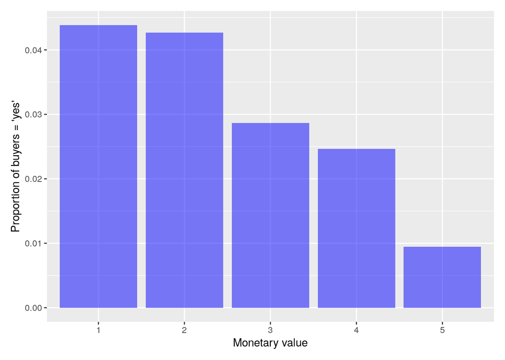

##### 5.Create bar charts showing the average amount spent (in RMB) (i.e., ordersize) per recency, frequency, and monetary quintile using only those customers who placed an order after the push message. Hint: constrain the data used for the plot with a “filter”.

```r
one_more=tuango_new %>% filter(buyer=='yes')

ave_rec=one_more%>% group_by(rec_iq) %>% summarize(ave=mean(ordersize))

ave_fre=one_more%>% group_by(fre_iq) %>% summarize(ave=mean(ordersize))

ave_mon=one_more%>% group_by(mon_iq) %>% summarize(ave=mean(ordersize))
```

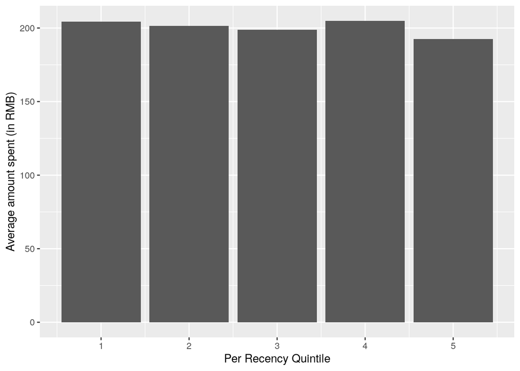

```r
ave_rec%>%ggplot(aes(x=rec_iq,y=ave))+geom_bar(stat='identity')+labs(x='Per Recency Quintile',y='Average amount spent (in RMB)')
```

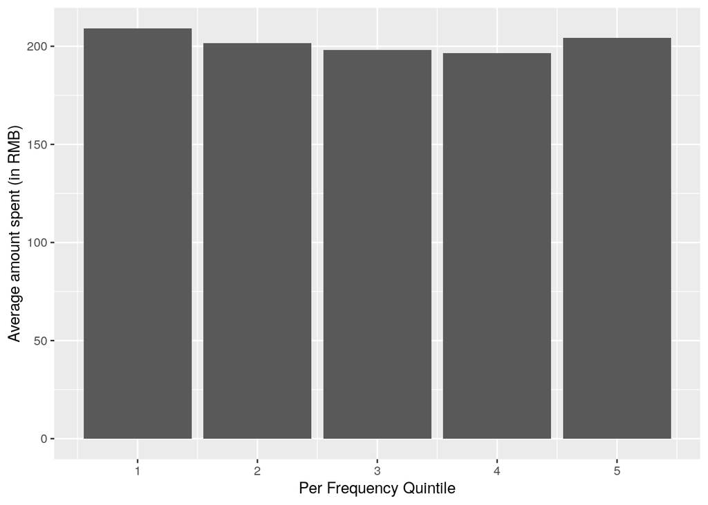

```r
ave_fre%>%ggplot(aes(x=fre_iq,y=ave))+geom_bar(stat='identity')+labs(x='Per Frequency Quintile',y='Average amount spent (in RMB)')
```

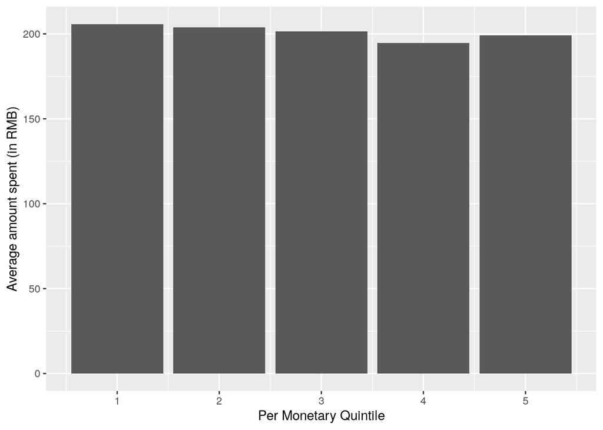

```r
ave_mon%>%ggplot(aes(x=mon_iq,y=ave))+geom_bar(stat='identity')+labs(x='Per Monetary Quintile',y='Average amount spent (in RMB)')
```

##### 6.What do the above bar charts reveal about the likelihood of response and the size of the order across the different recency, frequency, and monetary quintiles?

1. The more frequent,recent and monetary the customer is, the higher the response rate is.
2. Using only those customers who placed an order after the push message, the average amount spent has no difference across different recency, frequency, and monetary quintiles.

#### Part II: Profitability Analysis

```r
#First, create a variable rfm_iq using the independent n-tile approach.
rfm_iq=paste0(rec_iq,fre_iq,mon_iq)

rfm_iq[rfm_iq!=tuango$rfm_iq_pre] #As a way to check you have done this correctly, compare your index to the variable rfm_iq_pre
```

```
character(0)
```

```r
#Next, create a variable rfm_sq using the sequential n-tile approach.
tuango_sq <- tuango_new%>% group_by(rec_iq) %>%
  mutate(fre_sq = xtile(frequency, 5, rev = TRUE)) %>%
  ungroup()

## calculate sequential monetary quintiles
 tuango_sq<- tuango_sq%>% group_by(rec_iq, fre_sq) %>%
  mutate(mon_sq = xtile(monetary, 5, rev = TRUE)) %>%
  ungroup()

 tuango_sq$rec_sq=tuango_sq$rec_iq
 tuango_sq=tuango_sq%>%mutate(rfm_sq=paste0(rec_sq,fre_sq,mon_sq))
```

##### 7. What is the breakeven response rate?

```r
# Marginal cost to offer a deal is 2.5RMB
# Fee on each deal sold is 50% of sales revenues

cost_to_push=2.5
margin_on_sales=ave_amount*0.5
breakeven_respon=cost_to_push/margin_on_sales
breakeven_respon
```

```
[1] 0.02473671
```

##### 8. What is the projected profit in RMB and the return on marketing expenditures if you offer the deal to all 250,902 remaining customers?

```r
target_customers=250902
responsed_customers=ave_respon_rate*target_customers
profit=responsed_customers*margin_on_sales-target_customers*cost_to_push
profit
```

```
[1] 128605.5
```

```r
ROME=profit/(target_customers*cost_to_push)
ROME
```

```
[1] 0.2050291
```

##### 9. Evaluate the performance implications of offering the deal to only those customers (out of 250,902) in RFM cells with a response rate greater than the breakeven response rate. Generate your result based on both sequential and independent RFM. Determine the projected profit in RMB and the return on marketing expenditures for each approach.

```r
mailto_iq=tuango_new %>% group_by(rfm_iq_pre) %>% mutate(mailto=mean(buyer=='yes')>breakeven_respon)
mailto_sq=tuango_sq %>% group_by(rfm_sq) %>% mutate(mailto=mean(buyer=='yes')>breakeven_respon)

perf_calc = function (df,target_customers,margin_on_sales,cost_to_push,sms,intro) {
mailto_prop=sum(df$mailto)/nrow(df)
mailed_customers=mailto_prop*target_customers
mailed=df %>% filter(mailto==TRUE)
expected_response_rate=mean(mailed$buyer=='yes')
exp_respon_cus=expected_response_rate*mailed_customers
mailing_cost=mailed_customers*cost_to_push
profit=exp_respon_cus*margin_on_sales-mailing_cost
ROME=profit/mailing_cost
result=data.frame(sms=sms,intro=intro,expected_response_rate=expected_response_rate,exp_respon_cus=exp_respon_cus,mailing_cost=mailing_cost,profit=profit,ROME=ROME)
return (result)
}

res_iq=perf_calc(mailto_iq,target_customers,margin_on_sales,cost_to_push,sms = "smsto_iq", intro = "Based on independent quantile RFM")
res_sq=perf_calc(mailto_sq,target_customers,margin_on_sales,cost_to_push,sms = "smsto_sq", intro = "Based on sequantial quantile RFM")

diff_iq_sq=rbind(res_sq,res_iq)
diff_iq_sq
```

```
       sms                             intro expected_response_rate exp_respon_cus mailing_cost   profit     ROME
1 smsto_sq  Based on sequantial quantile RFM             0.05682804           5895       259335 336439.5 1.297316
2 smsto_iq Based on independent quantile RFM             0.05414115           6048       279270 331967.4 1.188697
```

Based on sequantial RFM,the profit is 336439.5RMB, ROME 1.297316, which are higher than independent RFM.  
Based on independent RFM,the profit is 331967.4, ROME 1.188697.  
So sequantial RFM outperformed independent RFM.

##### 10. What do you notice when you compare the rfm_iq and rfm_sq variables? That is – do the two approaches generally yield the same RFM index for any given customer?

No. The indexes are not the same.

```r
diff=tuango_sq[tuango_sq$rfm_iq_pre!=tuango_sq$rfm_sq,]
diff
```

```
# A tibble: 10,284 x 17
   userid    recency frequency monetary rfm_iq_pre buyer ordersize platform category mobile_os rec_iq fre_iq mon_iq fre_sq mon_sq rec_sq rfm_sq
   <chr>       <int>     <int>    <dbl> <chr>      <fct>     <dbl> <fct>       <int> <fct>      <int>  <int>  <int>  <int>  <int>  <int> <chr>
 1 U96495706     101         4     70   533        no            0 Browser         3 android        5      3      3      3      4      5 534
 2 U79189310      79         4     37.6 534        no            0 App             3 android        5      3      4      3      5      5 535
 3 U67701028      78         1     72.9 453        no            0 App             3 android        4      5      3      5      2      4 452
 4 U93348582      62         6     36.9 414        no            0 App             3 android        4      1      4      2      4      4 424
 5 U19691266      44         6     19.8 415        no            0 App             3 android        4      1      5      2      5      4 425
 6 U68753238      28         4    108   332        no            0 App             3 android        3      3      2      3      3      3 333
 7 U43344148      16         2     36   244        no            0 App             3 android        2      4      4      5      4      2 254
 8 U41921084      15         2     31   244        no            0 Browser         3 others         2      4      4      5      4      2 254
 9 U11113033      14         2     35   244        no            0 App             3 android        2      4      4      5      4      2 254
10 U67723307      13         6     19   215        no            0 App             3 android        2      1      5      2      5      2 225
# … with 10,274 more rows
```

##### What do you see as the pros and cons of the two approaches (from a statistical as well as logical perspective) and why?

Independent index:  
Pros: Logically,easier to interpret. It simply divided the all of people into groups in terms of F,R,M.  
Cons: Statistically, it makes the proportion of buyers less evenly distributed in different RFM index

Sequential index:  
Pros: Statistically, it makes the proportion of buyers more evenly distributed in different RFM index. In this case, the profit and ROME are higher than those of independent approach.  
Cons: Logically, it’s more complicated to explain than independent index. If people buy something cheap frequently. He is compared with people who buy cheap stuffs rather than with all of the people.

##### 11. The answer to question 9 assumes a single breakeven response rate that applies acrossall cells. Redo your analysis for sequential RFM based on a breakeven response rate calculated for each RFM cell.

Note: To project the expected profits for the remaining customers not part of the sample you can use Tuango’s standard fee and the ordersize number you calculated for question 2.

```r
tuango_perrfm=tuango_sq %>% filter(buyer=='yes') %>% group_by(rfm_sq) %>% summarise(ave_amount=mean(ordersize)) %>% mutate(breakeven_respon=cost_to_push/(0.5*ave_amount))

#we don't need to send push to those bins without buyers because the break-even rate is infinitely large but the expected response rate =0

response_rate_perrfm=tuango_sq %>% group_by(rfm_sq) %>% summarise(respon_rate=mean(buyer=='yes'),number=n())

tuango_per_rfm=tuango_perrfm %>% left_join(response_rate_perrfm,by='rfm_sq') %>% filter(respon_rate>breakeven_respon)

tuango_sq_per = tuango_sq %>% mutate(mailto=rfm_sq %in% tuango_per_rfm$rfm_sq)

res_per_sq=perf_calc(tuango_sq_per,target_customers,margin_on_sales,cost_to_push,sms = "per_rfm_sq", intro = "Based on per sequantial RFM")
```

The expected profit is 335808.6RMB and the ROME is 1.231421,which are not higher than the previous one. So I prefer using a sequantial RFM than breakeven response rate calculated for each RFM cell.

##### 12. The answer to question 9 does not account for the fact that the response rate for each cell is an estimated quantity (i.e., it has a standard error). Redo your analysis for both independent and sequential RFM, adjusting for the standard error of the response rate in each cell. What implications can you draw from the difference in predicted performance compared to question 9?

```r
mailto_lbiq=tuango_new %>% group_by(rfm_iq_pre) %>% mutate(lb=mean(buyer=='yes')-1.64*seprop(buyer=='yes'), mailto=lb>breakeven_respon)

mailto_lbsq=tuango_sq %>% group_by(rfm_sq) %>% mutate(lb=mean(buyer=='yes')-1.64*seprop(buyer=='yes'), mailto=lb>breakeven_respon)

res_iq_se=perf_calc(mailto_lbiq,target_customers,margin_on_sales,cost_to_push,sms = "smsto_iq_se", intro = "Based on independent quantile RFM")

res_sq_se=perf_calc(mailto_lbsq,target_customers,margin_on_sales,cost_to_push,sms = "smsto_sq_se", intro = "Based on sequantial RFM")


#the difference in independent RFM:
diff_iq_se=rbind(res_iq_se,res_iq)


#the difference in sequantial RFM:

diff_sq_se=rbind(res_sq_se,res_sq)
```

If we use standard error to set a lowerbound of the response rate to compare the breakeven response rate, we will send fewer sms. That will reduce our mailing cost. The expected response rate will increase.  
But since we send to fewer customers, the total responded customers will be decreased and obviously the shrinking revenue caused shrinking profit.  
Although the ROMEs are higher than question9, the profits are lower. So I think we’d better not to use the lowerbound method.

##### 13. Create a bar chart with profit information and a bar chart with ROME numbers for the analyses conducted in questions 9, 11, and 12.

```r
compare_table=rbind(diff_iq_se,diff_sq_se,res_per_sq) %>% select(sms,profit,ROME)  %>% rename(method=sms)
print(compare_table)
```

```
       method   profit     ROME
1 smsto_iq_se 280372.4 2.058308
2    smsto_iq 331967.4 1.188697
3 smsto_sq_se 279385.3 1.970972
4    smsto_sq 336439.5 1.297316
5  per_rfm_sq 335808.6 1.231421
```

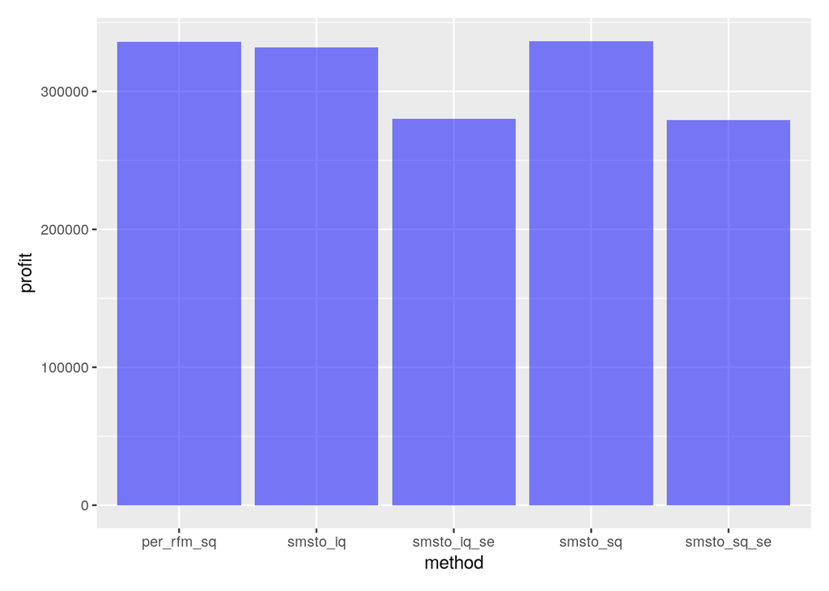

```r
#profit bar chart:
visualize(
  compare_table,
  xvar = "method",
  yvar = "profit",
  type = "bar",
  labs = list(
    y = "profit",
    x = "method"
  ),
  custom = FALSE
)
```

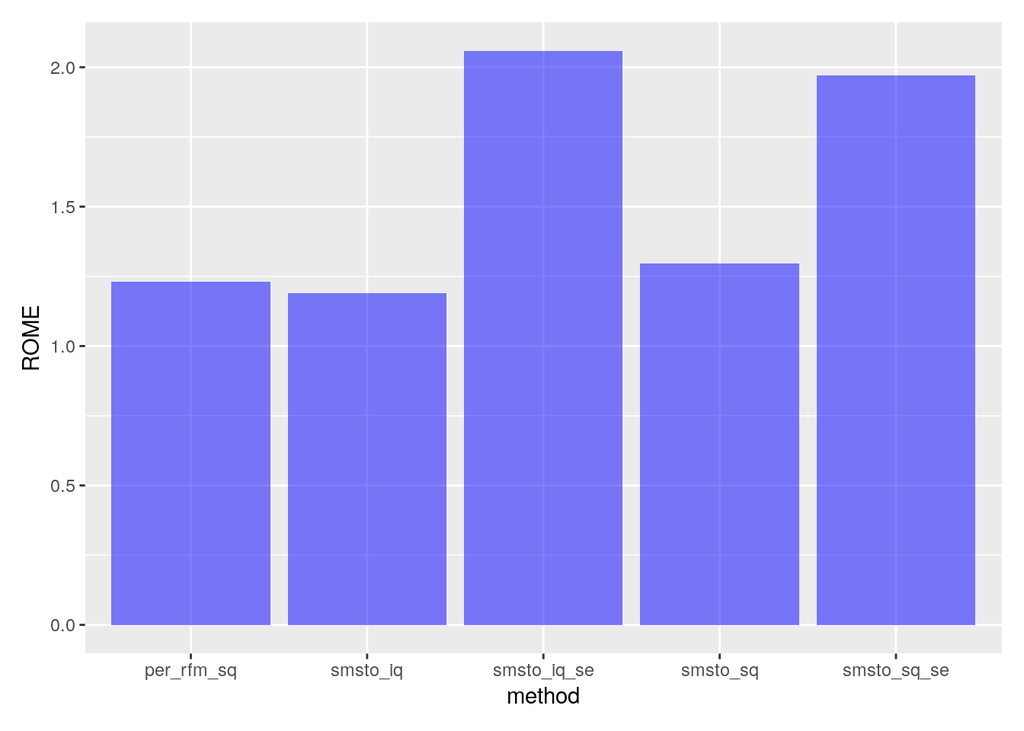

```r
#ROME bar chart:
visualize(
  compare_table,
  xvar = "method",
  yvar = "ROME",
  type = "bar",
  labs = list(
    y = "ROME",
    x = "method"
  ),
  custom = FALSE
)
```